# Analyzing Individual BGG Users

Phil Henrickson

2022-01-02

# **Echochee’s** BoardGameGeek Collection

This notebook contains a set of analyses for the selected user’s boardgamegeek collection. The bulk of the analysis is focused on building a user-specific predictive model to predict the games that Echochee is likely to own. This enables to ask questions like, based on the games the user currently owns, what games are a good fit for their collection? What upcoming games are they likely to purchase?

This analysis is based on data from BoardGameGeek that was last updated on **2021-12-20.**

# 1 Collection Overview

We can look at a basic description of the number of games that the user owns, has rated, has previously owned, etc.

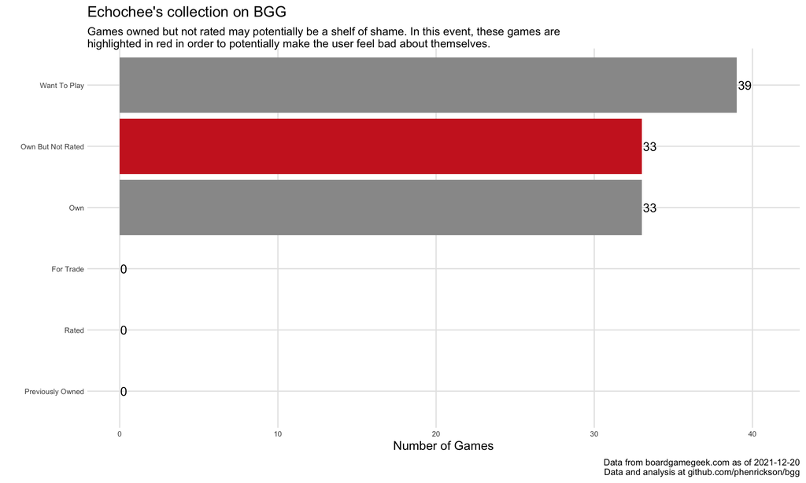

What years has the user owned/rated games from? While we can’t see when a user added or removed a game from their collection, we can look at their collection by the years in which their games were published.

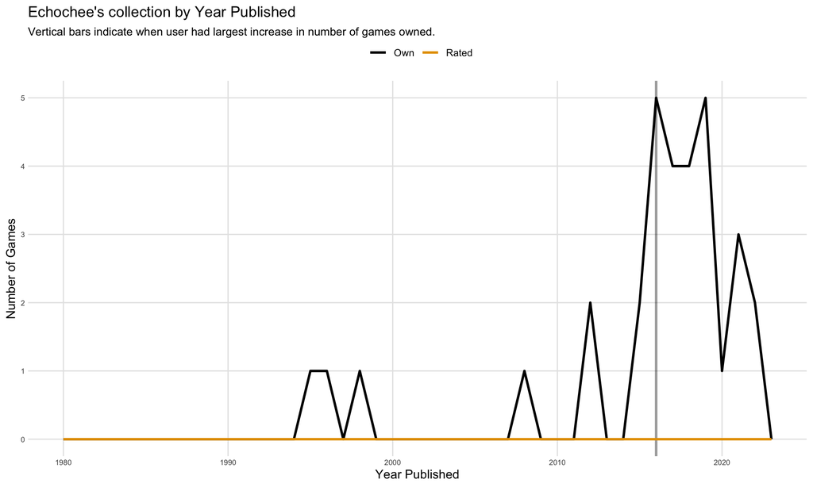

## 1.1 What types of games does Echochee own?

We can look at the most frequent types of categories, mechanics, designers, and artists that appear in a user’s collection.

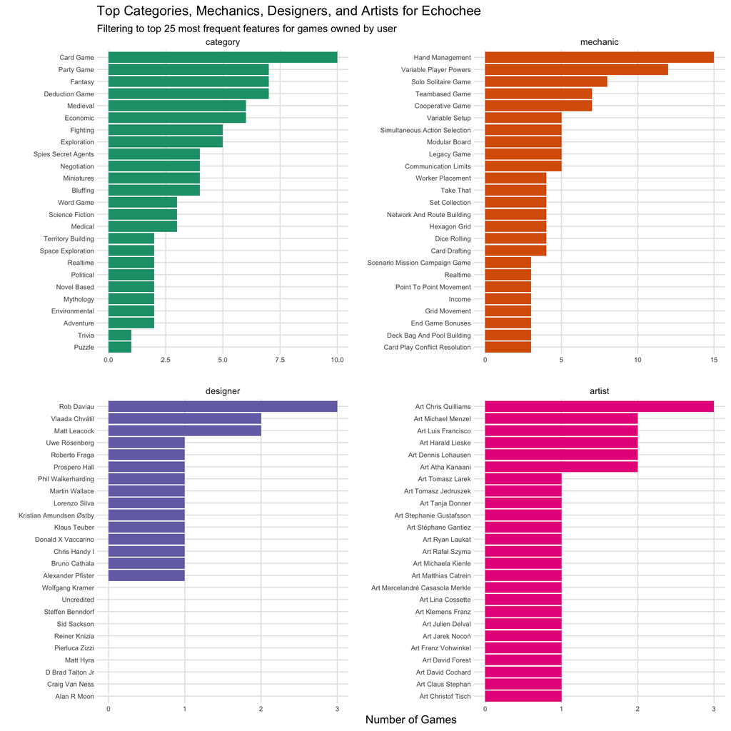

# 2 Modeling **Echochee’s** Collection

| username | dataset | period | games_owned | games_rated | games_played |
| --- | --- | --- | --- | --- | --- |
| Echochee | training | published before 2018 | 18 | 0 | 18 |
| Echochee | test | published 2018 or later | 15 | 0 | 15 |

There are two main (binary) outcomes we will be modeling for the user.

The first, **own** refers to whether the user currently lists a game as owned in their collection. The second, **played** refers to whether the user currently owns, has rated, or previously owned a game. This means the latter will generally have a larger list of games, but may still be a useful category to examine for people who play lots of games without necessarily owning them.

We will train predictive models to learn the probability that the user will own or play individual games based on their features.

## 2.1 Coefficients for Echochee

We can examine coefficients from the trained modes, which are penalized logistic regressions fit to our two main outcomes. Positive values indicate that a feature increases a user’s probabilility of owning/rating a game, while negative values indicate a feature decreases the probability.

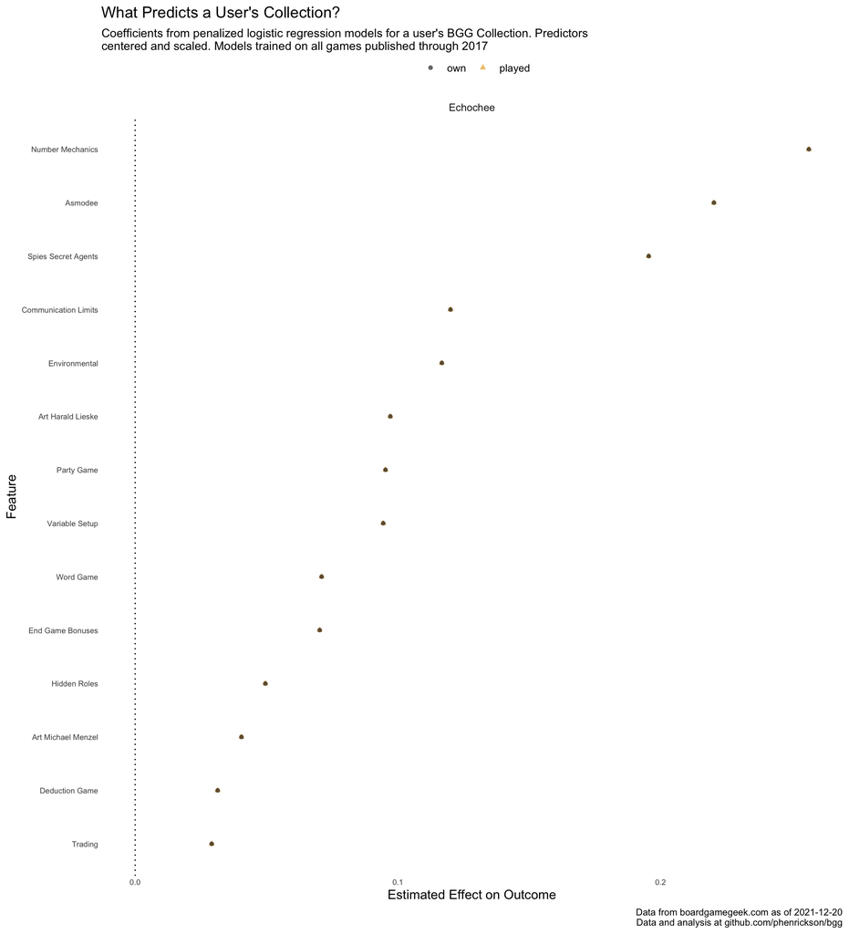

## 2.2 Visualizing Predictors for Echochee’s Collection

Why did the model identify these features? We can make density plots of the important features for predicting whether the user owned a game. Blue indicates the density for games owned by the user, while grey indicates the density for games not owned by the user.

[figure not shown]

Binary predictors can be difficult to see with this visualization, so we can also directly examine the percentage of games in a user’s collection with a predictor vs the percentage of all games with that predictor.

| username | Feature | % of Games with Feature In_Collection | % of Games with Feature All_Games | Ratio |
| --- | --- | --- | --- | --- |
| Echochee | Communication Limits | 16.7% | 0.7% | 24.8 |
| Echochee | Spies Secret Agents | 22.2% | 1.3% | 17.1 |
| Echochee | Hidden Roles | 11.1% | 0.7% | 15.8 |
| Echochee | Environmental | 11.1% | 1.0% | 11.7 |
| Echochee | End Game Bonuses | 11.1% | 1.0% | 11.7 |
| Echochee | Variable Setup | 16.7% | 1.7% | 9.5 |
| Echochee | Word Game | 16.7% | 1.8% | 9.4 |
| Echochee | Asmodee | 38.9% | 5.2% | 7.5 |
| Echochee | Deduction Game | 33.3% | 6.0% | 5.6 |
| Echochee | Teambased Game | 33.3% | 6.2% | 5.4 |
| Echochee | Trading | 16.7% | 3.4% | 4.8 |
| Echochee | Party Game | 38.9% | 8.7% | 4.5 |
| Echochee | Negotiation | 16.7% | 4.0% | 4.2 |
| Echochee | Trivia | 5.6% | 2.0% | 2.8 |
| Echochee | Medieval | 16.7% | 6.2% | 2.7 |
| Echochee | Puzzle | 5.6% | 2.8% | 2.0 |
| Echochee | City Building | 5.6% | 4.1% | 1.4 |
| Echochee | Realtime | 5.6% | 4.0% | 1.4 |
| Echochee | Horror | 0.0% | 3.7% | 0.0 |
| Echochee | Racing | 0.0% | 3.1% | 0.0 |
| Echochee | Action Dexterity | 0.0% | 5.1% | 0.0 |
| Echochee | Mafia | 0.0% | 0.7% | 0.0 |
| Echochee | Trains | 0.0% | 2.3% | 0.0 |
| Echochee | Prehistoric | 0.0% | 1.0% | 0.0 |
| Echochee | Sports | 0.0% | 2.2% | 0.0 |

# 3 Assess Model’s Performance on Training Set

Before predicting games in upcoming years, we can examine how well the model did and what games it liked in the training set. In this case, we used resampling techniques (cross validation) to ensure that the model had not seen a game before making its predictions.

## 3.1 Separation Plot

An easy way to examine the performance of classification model is to view a separation plot. We plot the predicted probabilities from the model for every game (from resampling) from lowest to highest. We then overlay a blue line for any game that the user does own. A good classifier is one that is able to *separate* the blue (games owned by the user) from the white (games not owned by the user), with most of the blue occurring at the highest probabilities (right side of the chart).

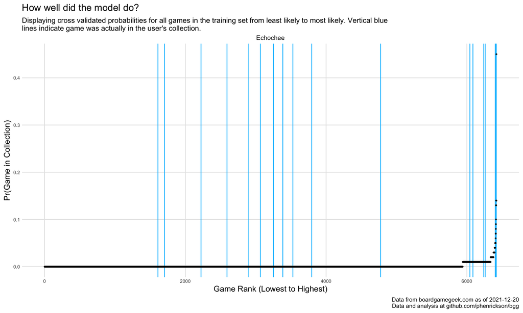

## 3.2 Top Games for **Echochee** from Training Set

We can display this information in table form, displaying the 100 games with the highest probability of ownership, adding a blue line when the user does own the game.

| username | yearpublished | game_id | name | pred_played | pred_own | actual_played | actual_own |
| --- | --- | --- | --- | --- | --- | --- | --- |
| Echochee | 2016 | 205158 | Codenames: Deep Undercover | 0.45 | 0.45 | 0 | 0 |
| Echochee | 2010 | 73171 | Earth Reborn | 0.14 | 0.14 | 0 | 0 |
| Echochee | 2015 | 178900 | Codenames | 0.14 | 0.14 | 1 | 1 |
| Echochee | 2014 | 156129 | Deception: Murder in Hong Kong | 0.14 | 0.14 | 0 | 0 |
| Echochee | 2017 | 224037 | Codenames: Duet | 0.13 | 0.13 | 0 | 0 |
| Echochee | 2004 | 11945 | Linq | 0.13 | 0.13 | 0 | 0 |
| Echochee | 2017 | 200847 | Secrets | 0.10 | 0.10 | 0 | 0 |
| Echochee | 2011 | 70919 | Takenoko | 0.09 | 0.09 | 0 | 0 |
| Echochee | 2016 | 198454 | When I Dream | 0.08 | 0.08 | 0 | 0 |
| Echochee | 2014 | 166384 | Spyfall | 0.07 | 0.07 | 0 | 0 |
| Echochee | 2016 | 198773 | Codenames: Pictures | 0.07 | 0.07 | 1 | 1 |
| Echochee | 2017 | 229370 | Rescue Polar Bears: Data & Temperature | 0.06 | 0.06 | 0 | 0 |
| Echochee | 2017 | 218603 | Photosynthesis | 0.05 | 0.05 | 0 | 0 |
| Echochee | 2017 | 174430 | Gloomhaven | 0.05 | 0.05 | 1 | 1 |
| Echochee | 1999 | 1353 | Time's Up! | 0.05 | 0.05 | 0 | 0 |
| Echochee | 2017 | 220775 | Codenames: Disney – Family Edition | 0.05 | 0.05 | 0 | 0 |
| Echochee | 2008 | 38713 | Time's Up! Edición Amarilla | 0.05 | 0.05 | 0 | 0 |
| Echochee | 2015 | 181304 | Mysterium | 0.05 | 0.05 | 0 | 0 |
| Echochee | 2010 | 62219 | Dominant Species | 0.05 | 0.05 | 0 | 0 |
| Echochee | 1948 | 320 | Scrabble | 0.04 | 0.04 | 0 | 0 |
| Echochee | 2008 | 34635 | Stone Age | 0.04 | 0.04 | 0 | 0 |
| Echochee | 2014 | 157354 | Five Tribes | 0.04 | 0.04 | 0 | 0 |
| Echochee | 2017 | 223931 | Sherlock Holmes Consulting Detective: Carlton House & Queen's Park | 0.04 | 0.04 | 0 | 0 |
| Echochee | 2016 | 204305 | Sherlock Holmes Consulting Detective: Jack the Ripper & West End Adventures | 0.04 | 0.04 | 0 | 0 |
| Echochee | 2015 | 176361 | One Night Revolution | 0.04 | 0.04 | 0 | 0 |
| Echochee | 2015 | 178054 | A Study in Emerald (Second Edition) | 0.04 | 0.04 | 0 | 0 |
| Echochee | 2015 | 143405 | Sylvion | 0.03 | 0.03 | 0 | 0 |
| Echochee | 2015 | 162865 | I, Spy | 0.03 | 0.03 | 0 | 0 |
| Echochee | 2010 | 25292 | Merchants & Marauders | 0.03 | 0.03 | 0 | 0 |
| Echochee | 2007 | 29937 | König von Siam | 0.03 | 0.03 | 0 | 0 |

[output cut: 70 more lines]

We can also more formally assess how well the model did in resampling by looking at the area under the receiver operating characteristic. A perfect model would receive a score of 1, while a model that cannot predict the outcome will default to a score of 0.5. The extent to which something is a *good* score depends on the setting, but generally anything in the .8 to .9 range is very good while the .7 to .8 range is perfectly acceptable.

| username | outcome_type | .metric | .estimator | .estimate |
| --- | --- | --- | --- | --- |
| Echochee | own | roc_auc | binary | 0.8 |
| Echochee | played | roc_auc | binary | 0.8 |

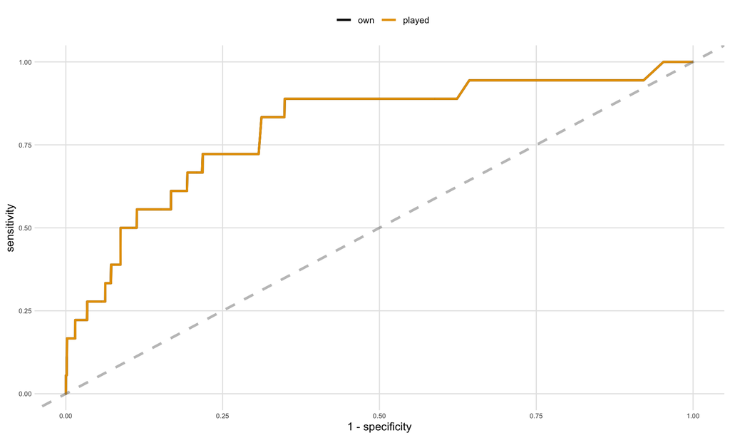

Another way to think about the model performance is to view its lift, or its ability to detect the positive outcomes over that of a null model. High lift indicates the model can much more quickly find all of the positive outcomes (in this case, games owned or played by the user), while a model with no lift is no better than random guessing.

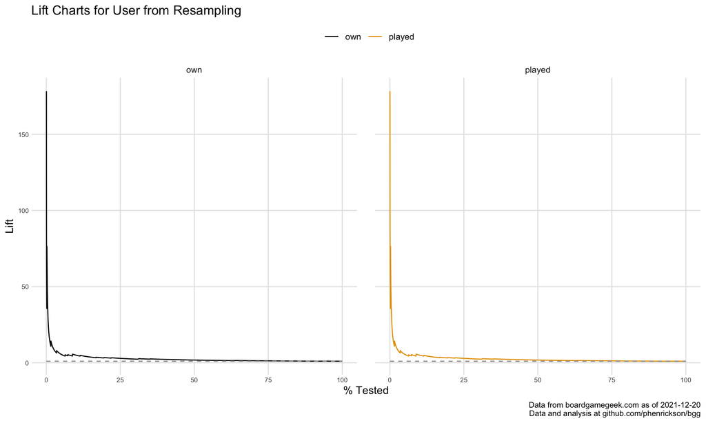

## 3.3 Most and Least Likely Games

What games does the model think Echochee is **most likely to own** that are **not** in their collection?

| username | yearpublished | game_id | name | pred_own | actual_own |
| --- | --- | --- | --- | --- | --- |
| Echochee | 2016 | 205158 | Codenames: Deep Undercover | 0.45 | 0 |
| Echochee | 2010 | 73171 | Earth Reborn | 0.14 | 0 |
| Echochee | 2014 | 156129 | Deception: Murder in Hong Kong | 0.14 | 0 |
| Echochee | 2017 | 224037 | Codenames: Duet | 0.13 | 0 |
| Echochee | 2004 | 11945 | Linq | 0.13 | 0 |

What games does the model think Echochee is **least likely to own** that **are** in their collection?

| username | yearpublished | game_id | name | pred_own | actual_own |
| --- | --- | --- | --- | --- | --- |
| Echochee | 2015 | 161936 | Pandemic Legacy: Season 1 | 0 | 1 |
| Echochee | 2017 | 221107 | Pandemic Legacy: Season 2 | 0 | 1 |
| Echochee | 2008 | 36218 | Dominion | 0 | 1 |
| Echochee | 2016 | 200680 | Agricola (Revised Edition) | 0 | 1 |
| Echochee | 2016 | 204583 | Kingdomino | 0 | 1 |

## 3.4 Top Games by Year

Top 25 games most likely to be owned by the user in each year, highlighting in blue the games that the user has owned/played.

| rank | 2009 | 2010 | 2011 | 2012 | 2013 | 2014 | 2015 | 2016 | 2017 |
| --- | --- | --- | --- | --- | --- | --- | --- | --- | --- |
| 1 | Time's Up! Academy | Earth Reborn | Takenoko | Terra Mystica | LEADERS: The Combined Strategy Game | Deception: Murder in Hong Kong | Codenames | Codenames: Deep Undercover | Codenames: Duet |
| 2 | Small World | Dominant Species | Tragedy Looper | Agents of SMERSH | Prosperity | Spyfall | Mysterium | When I Dream | Secrets |
| 3 | Jaipur | Merchants & Marauders | Dark Moon | Keyflower | BANG! The Dice Game | Five Tribes | One Night Revolution | Codenames: Pictures | Rescue Polar Bears: Data & Temperature |
| 4 | The Message | Hanabi | A Few Acres of Snow | NOIR: Deductive Mystery Game | Concept | [redacted] | A Study in Emerald (Second Edition) | Sherlock Holmes Consulting Detective: Jack the Ripper & West End Adventures | Photosynthesis |
| 5 | Ra: The Dice Game | Troyes | Friday | Catan: Family Edition | Two Rooms and a Boom | La Granja | Sylvion | Covert | Gloomhaven |
| 6 | Atlantis | Anomia | The Secret of Monte Cristo | War of the Ring: Second Edition | Tomorrow | Witness | I, Spy | Yokohama | Codenames: Disney – Family Edition |
| 7 | Shipyard | Labyrinth: The War on Terror, 2001 – ? | Discworld: Ankh-Morpork | Spartacus: A Game of Blood and Treachery | Impulse | Camel Up | 504 | Islebound | Sherlock Holmes Consulting Detective: Carlton House & Queen's Park |
| 8 | The Werewolves of Miller's Hollow: The Village | Cyrano | Mage Knight Board Game | Wiz-War (Eighth Edition) | Bomb Squad | Spurs: A Tale in the Old West | Burgle Bros. | Evolution: Climate | Spirit Island |
| 9 | Luna Llena: Full Moon | Key Market | Octopus's Garden | Seasons | Dungeon Twister: The Card Game | Smash Up: Science Fiction Double Feature | Homeland: The Game | Smash Up: It's Your Fault! | The Ruhr: A Story of Coal Trade |
| 10 | Clue: Secrets & Spies | Felinia | Mondo | Merchant of Venus (Second Edition) | Smash Up: Awesome Level 9000 | Akrotiri | ...and then, we held hands. | 13 Days: The Cuban Missile Crisis | Codenames: Marvel |
| 11 | Kansas Pacific | Two by Two | Bios: Megafauna | Kairo | The Ravens of Thri Sahashri | Patchwork | Agent Decker | Inis | Twilight Imperium: Fourth Edition |
| 12 | The Resistance | Ablaze! | Sour Apples to Apples | Santa Cruz | Agent Hunter | Castles of Mad King Ludwig | Coffee Roaster | V-Sabotage | Fugitive |
| 13 | Are You the Traitor? | Scrabble Flash | Dixit: Odyssey | Riff Raff | Legacy: The Testament of Duke de Crecy | Sons of Anarchy: Men of Mayhem | Haspelknecht | First Class: All Aboard the Orient Express! | Azul |
| 14 | You Robot | Nuns on the Run | Rory's Story Cubes: Voyages | Robinson Crusoe: Adventures on the Cursed Island | Tash-Kalar: Arena of Legends | Waggle Dance | Bastion | Hit Z Road | Magic Maze |
| 15 | Hansa Teutonica | Escape from the Aliens in Outer Space | Letters from Whitechapel | Love Letter | Corto | Deus | The Pursuit of Happiness | Quadropolis | Muse |
| 16 | Cyclades | Time's Up! Family | Eclipse | Secret Code 13+4 | Gunrunners | Abyss | Inhabit the Earth | Tyrants of the Underdark | LYNGK |
| 17 | Nostra City | 7 Wonders | New York | Wits & Wagers Party | Patchistory | Gardens | Runebound (Third Edition) | Aeon's End | Smash Up: What Were We Thinking? |
| 18 | Name 5 | Asteroyds | The Walking Dead: The Board Game | Timeline: General Interest | Mascarade | Alchemists | Far Space Foundry | Harry Potter: Hogwarts Battle | Fog of Love |
| 19 | Waterloo | Buzz It! | Dungeon Fighter | Exodus: Proxima Centauri | Space Sheep! | Good Cop Bad Cop | City of Spies: Estoril 1942 | Covalence: A Molecule Building Game | Pocket Ops |
| 20 | The Caucasus Campaign | Mousquetaires du Roy | Mundus Novus | Zombicide | Rory's Story Cubes: Prehistoria | Secret Moon | The Bloody Inn | Imhotep | Finished! |
| 21 | Grind | 20th Century | Flash Point: Fire Rescue | Android: Infiltration | Tajemnicze Domostwo | Ultimate Werewolf | Liguria | Pandemic: Reign of Cthulhu | Tortuga 1667 |
| 22 | Dungeon Twister 2: Prison | Sneaks & Snitches | Dr. Shark | Dixit: Journey | Room 25 | Trekking the National Parks | The King Is Dead | Mutant Crops | Banned Words |
| 23 | Space Hulk (Third Edition) | Nations at War: White Star Rising | Panic Station | Space Cadets | Anomia: Party Edition | Evolution | The Builders: Antiquity | Archer: Once You Go Blackmail... | Fallout |
| 24 | Hellenes: Campaigns of the Peloponnesian War | Battles of Napoleon: The Eagle and the Lion | Rumble in the House | Rumble in the Dungeon | Funemployed | Pictopia: Disney Edition | Dilluvia Project | Age of Thieves | Pendragon: The Fall of Roman Britain |
| 25 | The Halls of Montezuma | Washington's War | Band of Brothers: Screaming Eagles | Dixit Jinx | Ladies & Gentlemen | Hyperborea | Bretagne | Beyond Baker Street | Whitehall Mystery |

## 3.5 Interactive Predictions from Resampling

Interactive table for predictions from resampling.

|  | username | yearpublished | rank | game_id | name | pred_played | pred_own | actual_played | actual_own |
| --- | --- | --- | --- | --- | --- | --- | --- | --- | --- |
| 1 | Echochee | 1900 | 355 | 45 | Perudo | 0.01 | 0.01 | 0 | 0 |
| 2 | Echochee | 1900 | 492 | 5546 | Marbles | 0 | 0 | 0 | 0 |
| 3 | Echochee | 1900 | 495 | 11901 | Tic-Tac-Toe | 0 | 0 | 0 | 0 |
| 4 | Echochee | 1900 | 542 | 188 | Go | 0 | 0 | 0 | 0 |
| 5 | Echochee | 1900 | 645 | 171 | Chess | 0 | 0 | 0 | 0 |
| 6 | Echochee | 1900 | 656 | 2065 | Shogi | 0 | 0 | 0 | 0 |
| 7 | Echochee | 1900 | 658 | 2393 | Xiangqi | 0 | 0 | 0 | 0 |
| 8 | Echochee | 1900 | 852 | 26952 | International Checkers | 0 | 0 | 0 | 0 |
| 9 | Echochee | 1900 | 881 | 1602 | The Royal Game of Ur | 0 | 0 | 0 | 0 |
| 10 | Echochee | 1900 | 882 | 2083 | Checkers | 0 | 0 | 0 | 0 |

[output cut: 6410 more lines]

# 4 Validating the Model on 2018

How well did a model trained on a user’s collection through 2017 perform in predicting games for the user from 2018?

| username | outcome_type | yearpublished | .metric | .estimator | .estimate |
| --- | --- | --- | --- | --- | --- |
| Echochee | own | 2018 | roc_auc | binary | 0.654 |
| Echochee | played | 2018 | roc_auc | binary | 0.654 |

Table of top 25 games from 2018, highlighting games that the user owns.

| username | yearpublished | game_id | name | pred_own | pred_played | actual_own | actual_played |
| --- | --- | --- | --- | --- | --- | --- | --- |
| Echochee | 2018 | 225694 | Decrypto | 0.23 | 0.23 | 0 | 0 |
| Echochee | 2018 | 205896 | Rising Sun | 0.08 | 0.08 | 0 | 0 |
| Echochee | 2018 | 225167 | Human Punishment: Social Deduction 2.0 | 0.03 | 0.03 | 0 | 0 |
| Echochee | 2018 | 256877 | Hail Hydra | 0.03 | 0.03 | 0 | 0 |
| Echochee | 2018 | 235544 | Specter Ops: Broken Covenant | 0.02 | 0.02 | 0 | 0 |
| Echochee | 2018 | 244711 | Newton | 0.02 | 0.02 | 0 | 0 |
| Echochee | 2018 | 252776 | Muse: Awakenings | 0.02 | 0.02 | 0 | 0 |
| Echochee | 2018 | 258309 | First Contact | 0.02 | 0.02 | 0 | 0 |
| Echochee | 2018 | 167355 | Nemesis | 0.01 | 0.01 | 0 | 0 |
| Echochee | 2018 | 170604 | Renegade | 0.01 | 0.01 | 0 | 0 |
| Echochee | 2018 | 177659 | The Manhattan Project 2: Minutes to Midnight | 0.01 | 0.01 | 0 | 0 |
| Echochee | 2018 | 199792 | Everdell | 0.01 | 0.01 | 0 | 0 |
| Echochee | 2018 | 205127 | Haven | 0.01 | 0.01 | 0 | 0 |
| Echochee | 2018 | 205477 | Vengeance | 0.01 | 0.01 | 0 | 0 |
| Echochee | 2018 | 209324 | The World of SMOG: Rise of Moloch | 0.01 | 0.01 | 0 | 0 |
| Echochee | 2018 | 210274 | Petrichor | 0.01 | 0.01 | 0 | 0 |
| Echochee | 2018 | 214887 | CO₂: Second Chance | 0.01 | 0.01 | 0 | 0 |
| Echochee | 2018 | 218421 | Street Masters | 0.01 | 0.01 | 0 | 0 |
| Echochee | 2018 | 221371 | DC Spyfall | 0.01 | 0.01 | 0 | 0 |
| Echochee | 2018 | 222219 | Kero | 0.01 | 0.01 | 0 | 0 |
| Echochee | 2018 | 222509 | Lords of Hellas | 0.01 | 0.01 | 0 | 0 |
| Echochee | 2018 | 224517 | Brass: Birmingham | 0.01 | 0.01 | 1 | 1 |
| Echochee | 2018 | 224710 | Zombicide: Green Horde | 0.01 | 0.01 | 0 | 0 |
| Echochee | 2018 | 224904 | Sunset Over Water | 0.01 | 0.01 | 0 | 0 |
| Echochee | 2018 | 229853 | Teotihuacan: City of Gods | 0.01 | 0.01 | 0 | 0 |

# 5 Predicting Upcoming Games (2018 and On) for **Echochee**

Examine the top games for the test set.

| username | yearpublished | game_id | name | rank | own | played |
| --- | --- | --- | --- | --- | --- | --- |
| Echochee | 2018 | 225694 | Decrypto | 1 | 0.23 | 0.23 |
| Echochee | 2018 | 205896 | Rising Sun | 2 | 0.08 | 0.08 |
| Echochee | 2018 | 256877 | Hail Hydra | 3 | 0.03 | 0.03 |
| Echochee | 2018 | 225167 | Human Punishment: Social Deduction 2.0 | 4 | 0.03 | 0.03 |
| Echochee | 2018 | 252776 | Muse: Awakenings | 5 | 0.02 | 0.02 |
| Echochee | 2018 | 244711 | Newton | 6 | 0.02 | 0.02 |
| Echochee | 2018 | 235544 | Specter Ops: Broken Covenant | 7 | 0.02 | 0.02 |
| Echochee | 2018 | 258309 | First Contact | 8 | 0.02 | 0.02 |
| Echochee | 2018 | 247763 | Underwater Cities | 9 | 0.01 | 0.01 |
| Echochee | 2018 | 252929 | Planet | 10 | 0.01 | 0.01 |
| Echochee | 2018 | 224710 | Zombicide: Green Horde | 11 | 0.01 | 0.01 |
| Echochee | 2018 | 233312 | Stuffed Fables | 12 | 0.01 | 0.01 |
| Echochee | 2018 | 256952 | Zombie Kidz Evolution | 13 | 0.01 | 0.01 |
| Echochee | 2018 | 170604 | Renegade | 14 | 0.01 | 0.01 |
| Echochee | 2018 | 229853 | Teotihuacan: City of Gods | 15 | 0.01 | 0.01 |
| Echochee | 2018 | 210274 | Petrichor | 16 | 0.01 | 0.01 |
| Echochee | 2018 | 224904 | Sunset Over Water | 17 | 0.01 | 0.01 |
| Echochee | 2018 | 255708 | Trekking the National Parks: Second Edition | 18 | 0.01 | 0.01 |
| Echochee | 2018 | 244992 | The Mind | 19 | 0.01 | 0.01 |
| Echochee | 2018 | 242574 | Century: Eastern Wonders | 20 | 0.01 | 0.01 |
| Echochee | 2018 | 247236 | Duelosaur Island | 21 | 0.01 | 0.01 |
| Echochee | 2018 | 252328 | Star Wars: X-Wing (Second Edition) | 22 | 0.01 | 0.01 |
| Echochee | 2018 | 254591 | Heroes of Terrinoth | 23 | 0.01 | 0.01 |
| Echochee | 2018 | 257499 | Arkham Horror (Third Edition) | 24 | 0.01 | 0.01 |
| Echochee | 2018 | 224517 | Brass: Birmingham | 25 | 0.01 | 0.01 |
| Echochee | 2019 | 251247 | Barrage | 1 | 0.05 | 0.05 |
| Echochee | 2019 | 276025 | Maracaibo | 2 | 0.03 | 0.03 |
| Echochee | 2019 | 263155 | One Key | 3 | 0.03 | 0.03 |
| Echochee | 2019 | 266507 | Clank!: Legacy – Acquisitions Incorporated | 4 | 0.03 | 0.03 |
| Echochee | 2019 | 230244 | Black Angel | 5 | 0.02 | 0.02 |
| Echochee | 2019 | 242529 | Medium | 6 | 0.02 | 0.02 |
| Echochee | 2019 | 275467 | Letter Jam | 7 | 0.02 | 0.02 |
| Echochee | 2019 | 285253 | Fiesta de los Muertos | 8 | 0.02 | 0.02 |
| Echochee | 2019 | 265736 | Tiny Towns | 9 | 0.02 | 0.02 |
| Echochee | 2019 | 256960 | Pax Pamir: Second Edition | 10 | 0.02 | 0.02 |
| Echochee | 2019 | 252854 | Sabotage | 11 | 0.02 | 0.02 |
| Echochee | 2019 | 285984 | Last Bastion | 12 | 0.02 | 0.02 |
| Echochee | 2019 | 270971 | Era: Medieval Age | 13 | 0.02 | 0.02 |
| Echochee | 2019 | 217576 | Hellenica: Story of Greece | 14 | 0.01 | 0.01 |
| Echochee | 2019 | 286096 | Tapestry | 15 | 0.01 | 0.01 |
| Echochee | 2019 | 253574 | Crusader Kings | 16 | 0.01 | 0.01 |
| Echochee | 2019 | 249590 | Nevsky: Teutons and Rus in Collision 1240-1242 | 17 | 0.01 | 0.01 |
| Echochee | 2019 | 279644 | Peloponnesian War | 18 | 0.01 | 0.01 |
| Echochee | 2019 | 266192 | Wingspan | 19 | 0.01 | 0.01 |
| Echochee | 2019 | 269603 | Minecraft: Builders & Biomes | 20 | 0.01 | 0.01 |
| Echochee | 2019 | 251723 | Zombicide: Dark Side | 21 | 0.01 | 0.01 |
| Echochee | 2019 | 281946 | Aftermath | 22 | 0.01 | 0.01 |
| Echochee | 2019 | 264220 | Tainted Grail: The Fall of Avalon | 23 | 0.01 | 0.01 |
| Echochee | 2019 | 282524 | Horrified | 24 | 0.01 | 0.01 |
| Echochee | 2019 | 253635 | Ragusa | 25 | 0.01 | 0.01 |
| Echochee | 2020 | 291457 | Gloomhaven: Jaws of the Lion | 1 | 0.08 | 0.08 |
| Echochee | 2020 | 301767 | Mysterium Park | 2 | 0.04 | 0.04 |
| Echochee | 2020 | 314040 | Pandemic Legacy: Season 0 | 3 | 0.04 | 0.04 |
| Echochee | 2020 | 319966 | The King Is Dead: Second Edition | 4 | 0.03 | 0.03 |
| Echochee | 2020 | 292333 | Cowboys II: Cowboys & Indians Edition | 5 | 0.03 | 0.03 |
| Echochee | 2020 | 305498 | Tomorrow Dies Today | 6 | 0.02 | 0.02 |
| Echochee | 2020 | 307002 | Regicide | 7 | 0.02 | 0.02 |
| Echochee | 2020 | 296498 | 10 Dice | 8 | 0.02 | 0.02 |
| Echochee | 2020 | 312786 | Poetry for Neanderthals | 9 | 0.02 | 0.02 |
| Echochee | 2020 | 256317 | Guild Master | 10 | 0.02 | 0.02 |
| Echochee | 2020 | 302734 | Master Word | 11 | 0.02 | 0.02 |
| Echochee | 2020 | 295646 | Spyfest | 12 | 0.02 | 0.02 |
| Echochee | 2020 | 263421 | Enigma: Beyond Code | 13 | 0.02 | 0.02 |
| Echochee | 2020 | 323784 | Ghost Letters | 14 | 0.02 | 0.02 |
| Echochee | 2020 | 294235 | Crime Zoom: His Last Card | 15 | 0.01 | 0.01 |
| Echochee | 2020 | 321305 | Crime Zoom: A Bird of Ill Omen | 16 | 0.01 | 0.01 |
| Echochee | 2020 | 302465 | Obsidia | 17 | 0.01 | 0.01 |
| Echochee | 2020 | 203321 | This War Without an Enemy | 18 | 0.01 | 0.01 |
| Echochee | 2020 | 245224 | La Belle Époque | 19 | 0.01 | 0.01 |
| Echochee | 2020 | 280162 | From Salerno to Rome: World War II – The Italian Campaign, 1943-1944 | 20 | 0.01 | 0.01 |
| Echochee | 2020 | 285193 | Brief Border Wars | 21 | 0.01 | 0.01 |
| Echochee | 2020 | 300531 | Paleo | 22 | 0.01 | 0.01 |
| Echochee | 2020 | 316412 | The LOOP | 23 | 0.01 | 0.01 |
| Echochee | 2020 | 320505 | Mattock | 24 | 0.01 | 0.01 |
| Echochee | 2020 | 293889 | Fallout Shelter: The Board Game | 25 | 0.01 | 0.01 |

## 5.1 Interactive Table for Upcoming Games 2018 and On

|  | username | yearpublished | game_id | name | rank | own | played |
| --- | --- | --- | --- | --- | --- | --- | --- |
| 1 | Echochee | 2018 | 225694 | Decrypto | 1 | 0.23 | 0.23 |
| 2 | Echochee | 2020 | 291457 | Gloomhaven: Jaws of the Lion | 2 | 0.08 | 0.08 |
| 3 | Echochee | 2018 | 205896 | Rising Sun | 3 | 0.08 | 0.08 |
| 4 | Echochee | 2019 | 251247 | Barrage | 4 | 0.05 | 0.05 |
| 5 | Echochee | 2020 | 301767 | Mysterium Park | 5 | 0.04 | 0.04 |
| 6 | Echochee | 2020 | 314040 | Pandemic Legacy: Season 0 | 6 | 0.04 | 0.04 |
| 7 | Echochee | 2020 | 319966 | The King Is Dead: Second Edition | 7 | 0.03 | 0.03 |
| 8 | Echochee | 2019 | 276025 | Maracaibo | 8 | 0.03 | 0.03 |
| 9 | Echochee | 2018 | 256877 | Hail Hydra | 9 | 0.03 | 0.03 |
| 10 | Echochee | 2020 | 292333 | Cowboys II: Cowboys &amp; Indians Edition | 10 | 0.03 | 0.03 |

[output cut: 1923 more lines]